# HW_7_Geary_Veth

Chloe Veth and Marion Geary

2/24/2022

```r
library(tidyverse)
library(tidymodels)
library(mlbench)
data("Ozone")
```

## Exercise 1

```r
ozone <- Ozone %>% rename("month" = V1, "day_of_month" = V2, "day_of_week" = V3, "reading" = V4, "pressure_height" = V5, "wind_speed" = V6, "humidity%" = V7, "sandburg_temp" = V8, "el_monte_temp" = V9, "inversion_height" = V10, "pressure_gradient" = V11, "inversion_temp" = V12, "visibility" = V13)
ozone <- ozone %>% mutate(month = as.numeric(month), day_of_month = as.numeric(day_of_month), day_of_week = as.numeric(day_of_week))
```

## Exercise 2

```r
summary(ozone)
```

```
##      month         day_of_month    day_of_week       reading
##  Min.   : 1.000   Min.   : 1.00   Min.   :1.000   Min.   : 1.00
##  1st Qu.: 4.000   1st Qu.: 8.00   1st Qu.:2.000   1st Qu.: 5.00
##  Median : 7.000   Median :16.00   Median :4.000   Median : 9.00
##  Mean   : 6.514   Mean   :15.76   Mean   :4.003   Mean   :11.53
##  3rd Qu.: 9.750   3rd Qu.:23.00   3rd Qu.:6.000   3rd Qu.:16.00
##  Max.   :12.000   Max.   :31.00   Max.   :7.000   Max.   :38.00
##                                                   NA's   :5
##  pressure_height   wind_speed       humidity%     sandburg_temp
##  Min.   :5320    Min.   : 0.000   Min.   :19.00   Min.   :25.00
##  1st Qu.:5700    1st Qu.: 3.000   1st Qu.:49.00   1st Qu.:51.00
##  Median :5770    Median : 5.000   Median :65.00   Median :62.00
##  Mean   :5753    Mean   : 4.869   Mean   :58.48   Mean   :61.91
##  3rd Qu.:5830    3rd Qu.: 6.000   3rd Qu.:73.00   3rd Qu.:72.00
##  Max.   :5950    Max.   :11.000   Max.   :93.00   Max.   :93.00
##  NA's   :12                       NA's   :15      NA's   :2
##  el_monte_temp   inversion_height pressure_gradient inversion_temp
##  Min.   :27.68   Min.   : 111     Min.   :-69.0     Min.   :27.50
##  1st Qu.:49.73   1st Qu.: 890     1st Qu.:-10.0     1st Qu.:51.26
##  Median :57.02   Median :2125     Median : 24.0     Median :62.24
##  Mean   :56.85   Mean   :2591     Mean   : 17.8     Mean   :60.93
##  3rd Qu.:66.11   3rd Qu.:5000     3rd Qu.: 45.0     3rd Qu.:70.52
##  Max.   :82.58   Max.   :5000     Max.   :107.0     Max.   :91.76
##  NA's   :139     NA's   :15       NA's   :1         NA's   :14
##    visibility
##  Min.   :  0.0
##  1st Qu.: 70.0
##  Median :110.0
##  Mean   :123.3
##  3rd Qu.:150.0
##  Max.   :500.0
##
```

```r
ozone <- ozone %>% filter(!is.na(reading))
```

We might want to remove the missing values in the outcome so we can do supervised machine learning, where we need the outcomes. Without the outcome, we will not be able to assess how well our model is performing with missing values because there is not point of comparison for the prediction with the real value.

There are many variables with missing values including `pressure_height`, `humidity%`, `sandburg_temp`, `el_monte_temp`, `inversion_temp`, `inversion_height`, `pressure_gradient`.

## Exercise 3

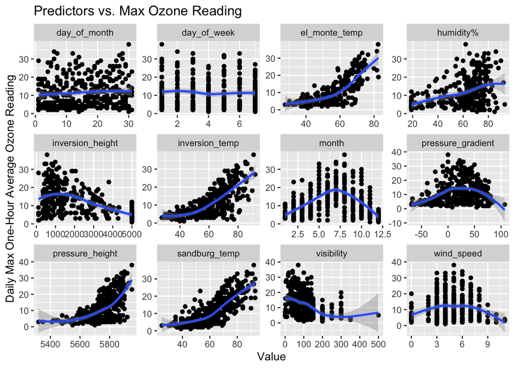

```r
ozone_longer <- ozone %>% pivot_longer(!reading, names_to="predictor", values_to="value")

ggplot(ozone_longer, aes(x = value, y = reading)) +
  geom_point() +
  geom_smooth(method = "loess") +
  facet_wrap(~predictor, scales="free") + labs(x = "Value", y = "Daily Max One-Hour Average Ozone Reading", title = "Predictors vs. Max Ozone Reading")
```

## Exercise 4

In the graphs, we see that many of the predictors appear to have an impact on `reading`. Many of the predictors do not have a linear relationship with `reading`. For example, `month`, `pressure_gradient`, `wind_speed`, and `inversion_height` have similar normal shapes, showing that values near the mean result in the highest predicted `reading`.

## Exercise 5

```r
set.seed(13)
ozone_split <- initial_split(ozone, prop = .8)
ozone_train <- training(ozone_split)
ozone_test <- testing(ozone_split)

ozone_recipe <- recipe(reading ~ ., data = ozone) %>%
  step_normalize(all_numeric_predictors()) %>%
  step_impute_knn(all_predictors(), neighbors = 5)

skimr::skim(bake(prep(ozone_recipe), new_data = ozone_train))
```

Data summary

| Name | bake(prep(ozone_recipe), … |
| --- | --- |
| Number of rows | 288 |
| Number of columns | 13 |
| _______________________ |  |
| Column type frequency: |  |
| numeric | 13 |
| ________________________ |  |
| Group variables | None |

**Variable type: numeric**

| skim_variable | n_missing | complete_rate | mean | sd | p0 | p25 | p50 | p75 | p100 | hist |
| --- | --- | --- | --- | --- | --- | --- | --- | --- | --- | --- |
| month | 0 | 1 | 0.02 | 1.00 | -1.58 | -0.79 | 0.14 | 1.01 | 1.58 | ▇▅▅▅▇ |
| day_of_month | 0 | 1 | -0.01 | 1.02 | -1.66 | -0.90 | -0.02 | 0.82 | 1.73 | ▇▆▆▆▆ |
| day_of_week | 0 | 1 | 0.01 | 0.99 | -1.50 | -1.00 | 0.00 | 1.00 | 1.50 | ▇▅▃▅▇ |
| pressure_height | 0 | 1 | 0.03 | 0.97 | -4.10 | -0.50 | 0.17 | 0.74 | 1.88 | ▁▁▃▇▅ |
| wind_speed | 0 | 1 | 0.02 | 1.02 | -2.30 | -0.88 | 0.06 | 0.53 | 2.88 | ▂▇▇▃▁ |
| humidity% | 0 | 1 | -0.01 | 0.99 | -1.98 | -0.56 | 0.34 | 0.69 | 1.75 | ▃▂▃▇▁ |
| sandburg_temp | 0 | 1 | 0.03 | 1.01 | -2.57 | -0.68 | 0.09 | 0.72 | 2.19 | ▁▅▇▇▃ |
| el_monte_temp | 0 | 1 | 0.08 | 0.95 | -2.48 | -0.53 | 0.09 | 0.83 | 2.21 | ▁▃▇▆▂ |
| inversion_height | 0 | 1 | -0.02 | 0.98 | -1.38 | -0.95 | -0.24 | 1.33 | 1.33 | ▇▅▃▂▇ |
| pressure_gradient | 0 | 1 | 0.00 | 0.98 | -2.39 | -0.73 | 0.18 | 0.76 | 1.78 | ▂▅▆▇▅ |
| inversion_temp | 0 | 1 | 0.04 | 0.99 | -2.40 | -0.66 | 0.15 | 0.72 | 2.23 | ▂▅▇▇▂ |
| visibility | 0 | 1 | 0.03 | 1.01 | -1.54 | -0.67 | -0.05 | 0.32 | 4.67 | ▇▇▃▂▁ |
| reading | 0 | 1 | 12.00 | 8.20 | 1.00 | 5.00 | 10.00 | 17.00 | 38.00 | ▇▅▃▂▁ |

In the knn imputation step, the recipe is using a knn model with `neighbors = 5` to impute the missing data. This means that it is using the knn model to estimate the missing values and fill them in to the dataframe.

## Exercise 6

```r
ozone_recipe <- ozone_recipe %>%
  step_corr(all_numeric_predictors())

skimr::skim(bake(prep(ozone_recipe), new_data = ozone_train))
```

Data summary

| Name | bake(prep(ozone_recipe), … |
| --- | --- |
| Number of rows | 288 |
| Number of columns | 11 |
| _______________________ |  |
| Column type frequency: |  |
| numeric | 11 |
| ________________________ |  |
| Group variables | None |

**Variable type: numeric**

| skim_variable | n_missing | complete_rate | mean | sd | p0 | p25 | p50 | p75 | p100 | hist |
| --- | --- | --- | --- | --- | --- | --- | --- | --- | --- | --- |
| month | 0 | 1 | 0.02 | 1.00 | -1.58 | -0.79 | 0.14 | 1.01 | 1.58 | ▇▅▅▅▇ |
| day_of_month | 0 | 1 | -0.01 | 1.02 | -1.66 | -0.90 | -0.02 | 0.82 | 1.73 | ▇▆▆▆▆ |
| day_of_week | 0 | 1 | 0.01 | 0.99 | -1.50 | -1.00 | 0.00 | 1.00 | 1.50 | ▇▅▃▅▇ |
| pressure_height | 0 | 1 | 0.03 | 0.97 | -4.10 | -0.50 | 0.17 | 0.74 | 1.88 | ▁▁▃▇▅ |
| wind_speed | 0 | 1 | 0.02 | 1.02 | -2.30 | -0.88 | 0.06 | 0.53 | 2.88 | ▂▇▇▃▁ |
| humidity% | 0 | 1 | -0.01 | 0.99 | -1.98 | -0.56 | 0.34 | 0.69 | 1.75 | ▃▂▃▇▁ |
| sandburg_temp | 0 | 1 | 0.03 | 1.01 | -2.57 | -0.68 | 0.09 | 0.72 | 2.19 | ▁▅▇▇▃ |
| inversion_height | 0 | 1 | -0.02 | 0.98 | -1.38 | -0.95 | -0.24 | 1.33 | 1.33 | ▇▅▃▂▇ |
| pressure_gradient | 0 | 1 | 0.00 | 0.98 | -2.39 | -0.73 | 0.18 | 0.76 | 1.78 | ▂▅▆▇▅ |
| visibility | 0 | 1 | 0.03 | 1.01 | -1.54 | -0.67 | -0.05 | 0.32 | 4.67 | ▇▇▃▂▁ |
| reading | 0 | 1 | 12.00 | 8.20 | 1.00 | 5.00 | 10.00 | 17.00 | 38.00 | ▇▅▃▂▁ |

## Exercise 7

```r
ozone_folds <- vfold_cv(ozone_train, v = 10, repeats = 5)

ozone_model <- linear_reg() %>% set_engine('lm')

ozone_wkflow <- workflow() %>%
  add_model(ozone_model) %>%
  add_recipe(ozone_recipe)

my_metrics <- metric_set(rmse, rsq)

ozone_pred <- control_resamples(save_pred = TRUE)

ozone_res <- ozone_wkflow %>% fit_resamples(resamples = ozone_folds, control = ozone_pred, metrics = my_metrics)

collect_metrics(ozone_res)
```

```
## # A tibble: 2 × 6
##   .metric .estimator  mean     n std_err .config
##   <chr>   <chr>      <dbl> <int>   <dbl> <chr>
## 1 rmse    standard   4.66     50  0.0812 Preprocessor1_Model1
## 2 rsq     standard   0.680    50  0.0131 Preprocessor1_Model1
```

The `rsq` value of 0.680 is decent. It indicates that 0.680 of the variation in `reading` is explained through the model. The value of `rmse` is 4.66, which is not super small. It shows that the average error is around 5, which is pretty high for data that ranges from 1 to 38.

## Exercise 8

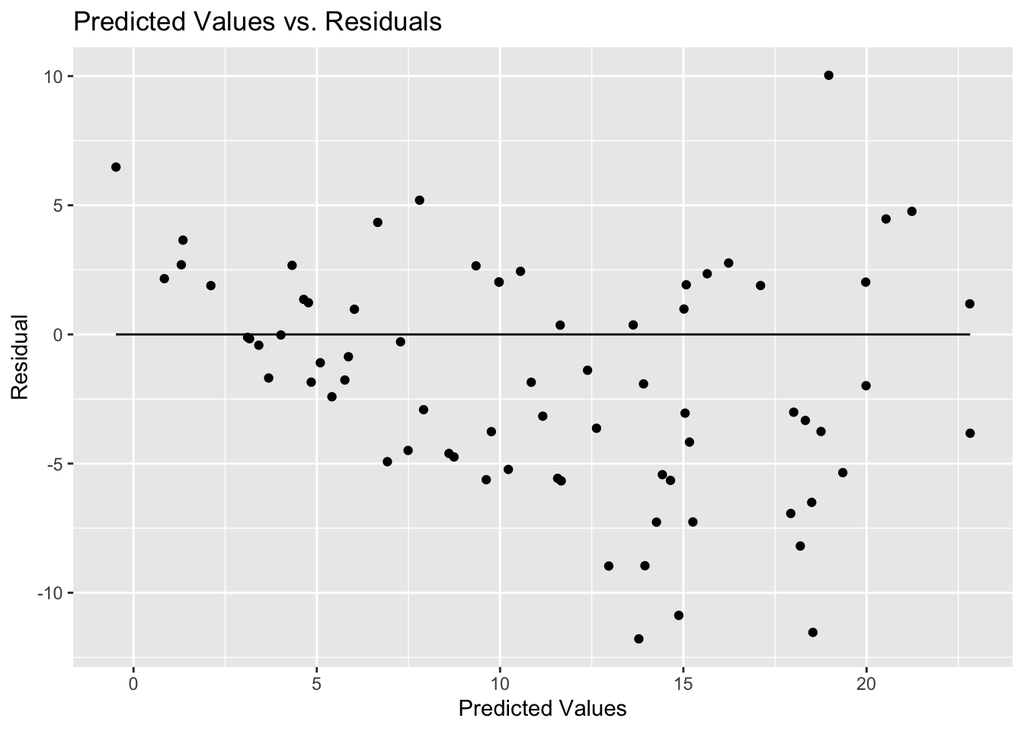

```r
ozone_fit <- fit(ozone_wkflow, data = ozone_train)
ozone_res_real <- augment(ozone_fit, new_data = ozone_test)

ggplot(ozone_res_real, aes(y = reading - .pred, x = .pred)) + geom_point() + labs(y = "Residual", x = "Predicted Values", title = "Predicted Values vs. Residuals") + geom_line(y = 0)
```

# Exercise 9

```r
elastic_net_mod <- linear_reg(penalty = tune(), mixture = tune()) %>%
    set_engine("glmnet")

elastic_net_wkflow <- workflow() %>%
    add_recipe(ozone_recipe) %>%
    add_model(elastic_net_mod)

penalty_grid <- expand_grid(grid_regular(penalty(), levels = 20), mixture = seq(from = 0, to = 1, by = 0.1))

elastic_net_res <- elastic_net_wkflow %>% tune_grid(resamples = ozone_folds, grid = penalty_grid)
elastic_metrics <- collect_metrics(elastic_net_res)
elastic_net_res %>% show_best(metric = "rmse")
```

```
## # A tibble: 5 × 8
##   penalty mixture .metric .estimator  mean     n std_err .config
##     <dbl>   <dbl> <chr>   <chr>      <dbl> <int>   <dbl> <chr>
## 1   0.298     0.6 rmse    standard    4.61    50  0.0803 Preprocessor1_Model139
## 2   0.298     0.5 rmse    standard    4.61    50  0.0804 Preprocessor1_Model119
## 3   0.298     0.7 rmse    standard    4.61    50  0.0804 Preprocessor1_Model159
## 4   0.298     0.8 rmse    standard    4.61    50  0.0805 Preprocessor1_Model179
## 5   0.298     0.4 rmse    standard    4.62    50  0.0807 Preprocessor1_Model099
```

# Exercise 10

The best `mixture` is 0.6 which shows that a pretty even split between lasso and ridge regression is the best for this data, with the L1 being weighted slightly more, showing a bit more influence from the lasso regression. The `penalty` shows that the summed value of the two penalty parameters is 0.298.

# Exercise 11

```r
final_workflow <- elastic_net_wkflow %>% finalize_workflow(select_best(elastic_net_res, metric = "rmse"))

final_fit <- final_workflow %>% fit_resamples(resamples = ozone_folds, control = ozone_pred, metrics = my_metrics)

collect_metrics(final_fit)
```

```
## # A tibble: 2 × 6
##   .metric .estimator  mean     n std_err .config
##   <chr>   <chr>      <dbl> <int>   <dbl> <chr>
## 1 rmse    standard   4.61     50  0.0803 Preprocessor1_Model1
## 2 rsq     standard   0.687    50  0.0129 Preprocessor1_Model1
```